# Ebola: Reproduction number and projection

Pierre Nouvellet & Anne Cori

2018-05-24

This file demonstrate how to use the ebolaproj package.

The package is used to estimate:

- the reproduction over a fixed time window
- project incidence forward from this time window

In doing so, no assumptions are made about the epidemic curve previous to the time window considered. in other words, estimate of Rt and forward projection are not conditionnal on incidence prior to the begining of the time window.

Therefore, in the inference, we infer the initial condition associated with a constant reproduction number that would have let to the incidence observed within the time window.

the procedure can be applied to multiple locations at the same time. if multiple locations are inputed, the dynamics in each locations are assumed independant.

# Simulating data

We first simulate data to be used for inference.

### Required packages

We use packages to simulate the data:

```r
library(incidence)
library(projections)
library(epitrix)
library(EpiEstim)
```

### Simulate incidence

We simulate starting with 20 cases, and serial interval relevant for Ebola.

We fix the reproduction number at 1.5 and simulate for 150 days and 50 locations.

We then keep only the last 28 days (4 weeks) of simulation which will be our time window.

Finally, we extract incidence for 10 locations only, making sure the incidence during that period is greater than 0.

# Infer reproduction number

First we load the package and data to test:

```r
rm(list = as.vector(ls()))

devtools::load_all('.')
## Loading ebolaproj


library(ebolaproj)
# load sample data to check
load(file = 'simulated.RData')

dim(incidence)
```

```
## [1] 28 11
```

NOTE: incidence dataframe includes:

- 1st column for dates and 10 locations
- 28 rows: the time window during which we assume Rt is constant

Then we produce necessary input object for the MCMC:

```r
# number of locations
N_geo <- ncol(incidence)-1

# Serial interval
mean_SI <- 14.2
CV_SI <- 9.6/14.2 # from http://www.nejm.org/doi/suppl/10.1056/NEJMc1414992/suppl_file/nejmc1414992_
SI <- SI_gamma_dist_EpiEstim(mu = mean_SI,
                            cv = CV_SI,
                            SItrunc = 40)
# final number of MCMC iterations (the whole thing,
# here with 10 locations runs in ~3.5mins) )
rep <- 2e3
sigma_prop <- rep(0.1,N_geo*2)         # initial proposal variances (they are now tuned!)
# initial incidence conditions
if ( N_geo>1 ){
  mu0 <- colMeans(incidence[,-1])*SI$SItrunc
}else{
  mu0 <- mean(incidence[,-1])*SI$SItrunc
}
# initially, we assume R=1 and choose initial condition accordingly, i.e. with mu0 case and R=1
# we expect the number of daily cases to stabilised at the mean of the observed incidence in the
# time window of interest
# this is use for the prior of initial number of cases, i.e. as the mean of an exponential distribution
# in practice, the mu0 cases will happen 100 days before the start of the time windows

theta0 <- c(rep(1,N_geo), mu0)          # initial parameter R=1 (time # of locations, and initial number of cases in the past)
```

We then run the MCMC:

```r
res <- MCMC_full(I = incidence,
                 N_geo = N_geo,
                 iter = rep,
                 theta0 = theta0,
                 s = sigma_prop,
                 SI = SI,
                 mu0 = mu0,
                 repli_adapt = 10,
                 within_iter = rep/10)
```

We can then check the traces of parameters and likelihood, acceptances, and get quantile for Rt.

```r
Acc <- colSums(diff(res$theta)!=0)/rep          # acceptance rate (should be close to .2)
Acc
```

```
##  [1] 0.1900 0.2235 0.2375 0.2130 0.1950 0.1795 0.1680 0.1660 0.2485 0.2270
## [11] 0.2150 0.1860 0.2225 0.1995 0.2440 0.1565 0.1930 0.1560 0.2450 0.1975
```

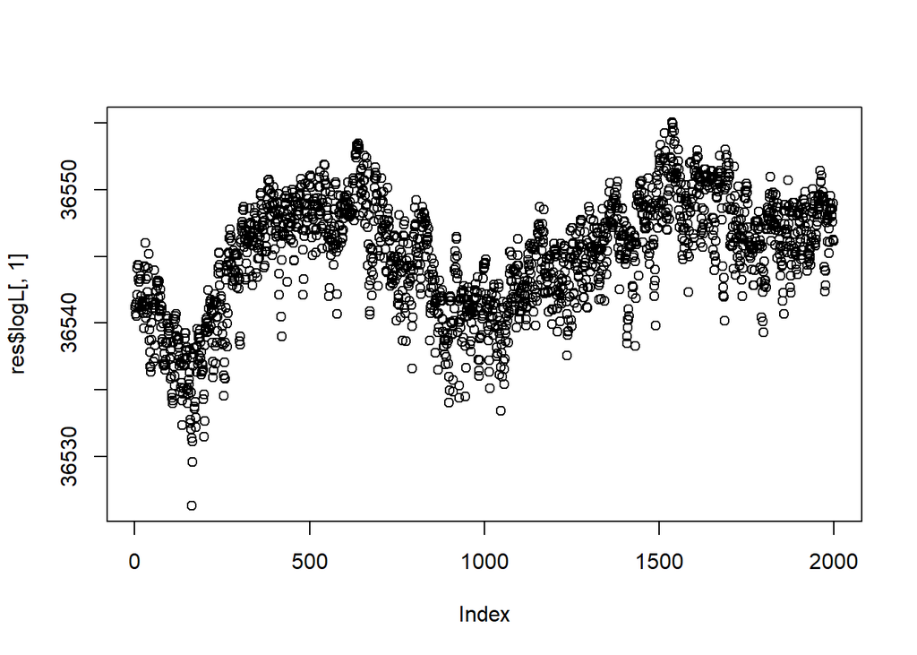

```r
# plot traces
plot(res$logL[,1])                                  # of likelihood
```

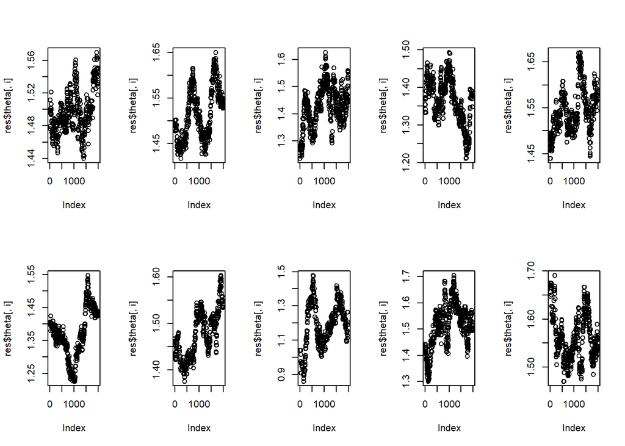

```r
layout(matrix(1:N_geo,2,ceiling(N_geo/2),byrow = TRUE))
for (i in 1:N_geo) plot(res$theta[,i])              # of R's
```

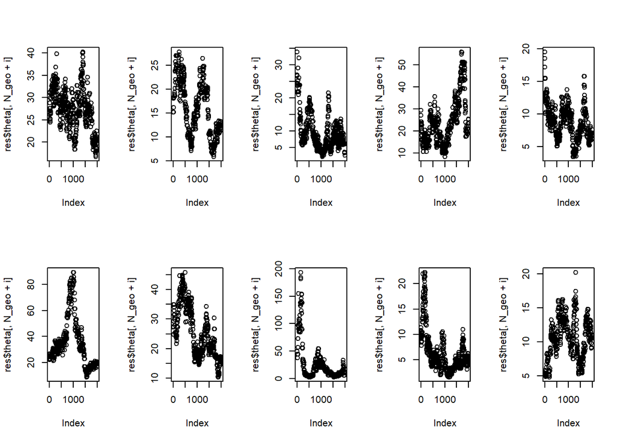

```r
for (i in 1:N_geo) plot(res$theta[,N_geo+i])        # of initial conditions
```

```r
if (N_geo>1){
  apply(res$theta[,1:N_geo],2,quantile,c(.5,.025,.975))   # median and 95%CrI of Rs by locations
}else{
  quantile(res$theta[,1],c(.5,.025,.975))
}
```

```
##           [,1]     [,2]     [,3]     [,4]     [,5]     [,6]     [,7]
## 50%   1.492910 1.502612 1.424368 1.367696 1.537290 1.365141 1.471343
## 2.5%  1.451638 1.428560 1.274986 1.251148 1.463467 1.232668 1.397926
## 97.5% 1.549142 1.619612 1.568879 1.461132 1.658784 1.510355 1.578911
##            [,8]     [,9]    [,10]
## 50%   1.1972063 1.526456 1.552250
## 2.5%  0.9153971 1.334961 1.490291
## 97.5% 1.4081066 1.650001 1.665674
```

```r
save.image('test_on_simulation1.RData')             # saving so far
```

# Project forward

Once we have inferred the reproduction numbers in the time window, and the initial conditions, we can use the same model to project forward.

We start the projection from the begining of the time window, to reflect incertainty in the initial conditions.

```r
# forward projection
Nsim <- 1e3                                           # number of simulation to get median and 95%CrI predictions
I_pred <- Proj_Pois(Results = res ,
                   Nsim = Nsim,
                   week_forward = 4+4,
                   N_geo = N_geo,
                   SI = SI)
# function to project forward, see Rscript/useful_functions.R
# needs the parameters estimated (Results)
# number of simulations
# week_forward: number of week projected from the START of the time window, SO: includes the period of time
# for which we have data!!! e.g. if we have 2 weeks of data and want to project for the 4 weeks
# after that, week_forward should be 6.
# require number of locations + serial interval
```

We finally plot the projections:

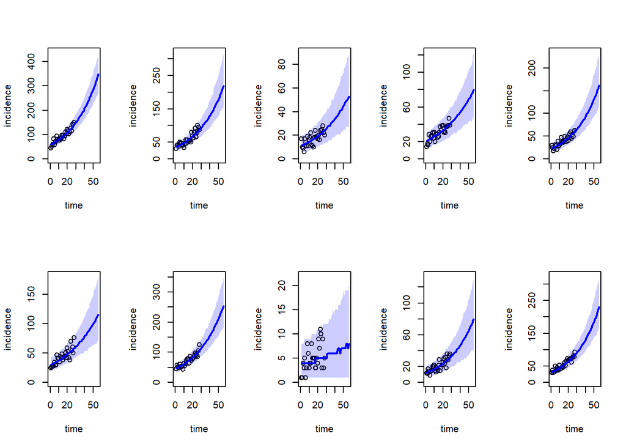

```r
# plot the observed incidence in the time window of interest and the median and 95%CrI predictions
layout(matrix(1:N_geo,2,ceiling(N_geo/2),byrow = TRUE))
for(i in 1:N_geo){
  CI_pred <- apply(I_pred[,i,101:dim(I_pred)[3]],2,quantile,c(.5,.025,.975))
  plot(1:nrow(incidence),incidence[,1+i],
       xlim=c(0,ncol(CI_pred)),
       ylim = c(0,1+max(c(incidence[,1+i],as.vector(CI_pred)))),
       xlab = 'time', ylab = 'incidence')

  x <- 1:ncol(CI_pred)
  lines(x,CI_pred[1,],col='blue',lwd=2)
  polygon(c(x,rev(x)), c(CI_pred[2,],rev(CI_pred[3,])),
          col = rgb(0,0,1,.2), border = FALSE )
}
```

# About this document

## Contributors

- Pierre Nouvellet & Anne Cori: initial version

## Legal stuff

**License**: [CC-BY](https://creativecommons.org/licenses/by/3.0/) **Copyright**: Pierre Nouvellet & Anne Cori, 2018